# vincent.ines

Inès Vincent

2026-04-12

# Association between handgrip strength and functional performance in Interstitial Lung Disease patients

## 0. Project accessibility The project is available on GitHub at this link:

https://github.com/inesvincent/Project_R_Python_M2_REHAB.git

## 1. Scientific problem

### 1.1. Context

Interstitial lung diseases (ILD) are a heterogeneous group of pulmonary disorders characterized by diffuse involvement of the lung interstitium, leading to impaired gas exchange and symptoms such as dyspnea and cough. These conditions are associated with reduced exercise tolerance and decreased physical capacity, impacting daily life (Collège des Enseignants de Pneumologie, 2023)

Although ILD primarily affects the respiratory system, it may indirectly alter overall physical function through reduced physical activity and deconditioning.

Handgrip strength is commonly used as a simple measure of upper-limb muscle strength and has been associated with functional performance and health outcomes (Bohannon, 2019; Norman et al., 2011). However, its ability to reflect overall muscle strength remains debated, with inconsistent associations reported depending on populations and methodologies (Szaflik et al., 2024).

Functional performance can be assessed using clinical tests such as walking speed and the five-times sit-to-stand (5STS) test, which reflect mobility, lower-limb strength, and overall functional capacity (Jones et al., 1999).

**What we are looking for:**  
To determine whether handgrip strength is associated with functional performance in patients with ILD, specifically with walking speed (4-meter walk test) and performance on the five-times sit-to-stand (5STS) test.

### 1.2. Aim

The aim of this study is to investigate the association between handgrip strength and functional performance in patients with ILD aged over 65 years, using walking speed and the five-times sit-to-stand (5STS) test as clinical measures

### 1.3. Method

Handgrip strength was used to assess upper-limb muscle strength. Functional performance was evaluated using the 4-meter walk test and the five-times sit-to-stand (5STS) test. Walking speed was derived from the 4-meter walk time using the following formula:

Walking speed (m/s) = 4 / walk_time_4m

### 1.5. Outcome measure

The main variables analyzed were handgrip strength, walking speed derived from the 4-meter walk test, and performance on the five-times sit-to-stand (5STS) test.

## 2. Aim of the code

The objective of this code is to analyze the association between handgrip strength and functional performance in patients with ILD. The analysis includes the assessment of normality using graphical methods and the application of correlation tests (Pearson or Spearman, depending on data distribution) to evaluate the relationships between handgrip strength, walking speed, and performance on the five-times sit-to-stand (5STS) test.

## 3. Data organization

**File:** `frapid_data_clean.csv`

**Columns:**
- `patient_id` : Patient identifier
- `age_years` : Age of the patient (in years)
- `gender` : Sex of the patient
- `handgrip_strength` : handgrip score :gives the muscular strength of the upper limbs (kg)
- `walk_time_4m` : Time (in seconds) taken by the patient to walk 4 meters - `time_5_raise_chair` : Time (in seconds) taken by the patient to perform 5 chair stands (5STS) - `walking_speed` : Walking speed (m/s), derived from the 4-meter walk test.
$$\text{Walking speed (m/s)} = \frac{4}{\text{walk time for 4m}}$$
—

## 4. Statistical analysis

The data were first imported after being cleaned. The normality of the variables was assessed using QQ plots and verified with a Shapiro-Wilk test. Based on this distribution, the choice of correlation test was adjusted: Pearson for normally distributed variables, and Spearman otherwise, as it is a nonparametric rank-based test. These tests allow us to assess the existence of an association between the variables, with estimation of p-values. Finally, a model adjusted for age and sex was developed to control for potential confounding factors.

### 4.1. Data import and preparation (section 5.1)

- **Aim:** To import the cleaned dataset and prepare variables for analysis.
- **Input:** `frapid_data_clean.csv` in `data/clean` folder
- **Output:** Dataset ready for statistical analysis, including derived variables such as walking speed.

### 4.2. Assessment of normality (section 5.2)

- **Aim:** To assess the distribution of the variables using graphical methods (QQ-plots).
- **Input:** Clean dataset
- **Output:** Graphical evaluation of normality for handgrip strength, walking speed, and 5STS performance.

### 4.3. Correlation analysis (section 5.3)

- **Aim:** To evaluate the association between handgrip strength and functional performance.
- **Input:** Clean dataset
- **Calculation:** Correlation tests (Pearson or Spearman) depending on data distribution.
- **Output:** Correlation coefficients and p-values indicating the strength and significance of the associations between:
  - handgrip strength and walking speed
  - handgrip strength and 5STS performance

### 4.4. Adjusted analysis (section 5.4)

- **Aim:** To adjust the associations for potential confounding variables (age and gender).
- **Input:** Clean dataset
- **Calculation:** Linear regression models including handgrip strength, age, and gender.
- **Output:** Regression coefficients and statistical significance of adjusted associations.

## 5. Code

### 5.0. Setup

This analysis was performed using base R functions. No additional packages are required.

### 5.1. Data import and preparation

The dataset was imported and checked to ensure correct structure and variable types.

```r
# Import dataset
data <- read.csv("data/clean/frapid_data_clean.csv")

# Check structure
str(data)
```

```
## 'data.frame':    46 obs. of  7 variables:
##  $ patient_id        : int  1 2 3 5 6 7 8 9 10 11 ...
##  $ age_years         : int  79 72 83 77 79 70 76 75 73 80 ...
##  $ gender            : chr  "M" "F" "M" "M" ...
##  $ handgrip_strength : int  35 22 24 26 20 32 30 16 18 24 ...
##  $ walk_time_4m      : num  2.7 4 3 4 2.7 2.7 9 2.5 4 2.2 ...
##  $ time_5_raise_chair: num  9 11 8 13 15 11 19 13 17 11 ...
##  $ walking_speed_mps : num  1.48 1 1.33 1 1.48 1.48 0.44 1.6 1 1.82 ...
```

```r
summary(data)
```

```
##    patient_id      age_years        gender          handgrip_strength
##  Min.   : 1.00   Min.   :66.00   Length:46          Min.   : 7.0
##  1st Qu.:13.25   1st Qu.:71.00   Class :character   1st Qu.:24.0
##  Median :24.50   Median :76.50   Mode  :character   Median :30.0
##  Mean   :24.43   Mean   :76.24                      Mean   :29.5
##  3rd Qu.:35.75   3rd Qu.:80.00                      3rd Qu.:36.0
##  Max.   :47.00   Max.   :89.00                      Max.   :50.0
##   walk_time_4m   time_5_raise_chair walking_speed_mps
##  Min.   :1.500   Min.   : 5.00      Min.   :0.4400
##  1st Qu.:2.500   1st Qu.:10.25      1st Qu.:0.8675
##  Median :3.000   Median :12.00      Median :1.3300
##  Mean   :3.562   Mean   :13.54      Mean   :1.3272
##  3rd Qu.:4.628   3rd Qu.:15.00      3rd Qu.:1.6000
##  Max.   :9.000   Max.   :36.00      Max.   :2.6700
```

### 5.2. Assessment of normality

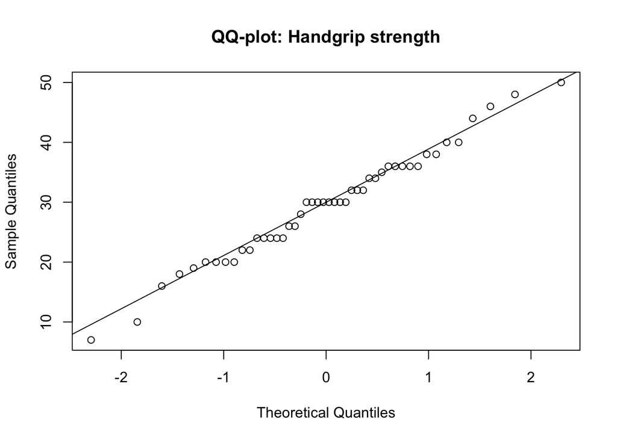

```r
# QQ-plot for normality
qqnorm(data$handgrip_strength, main = "QQ-plot: Handgrip strength")
qqline(data$handgrip_strength)
```

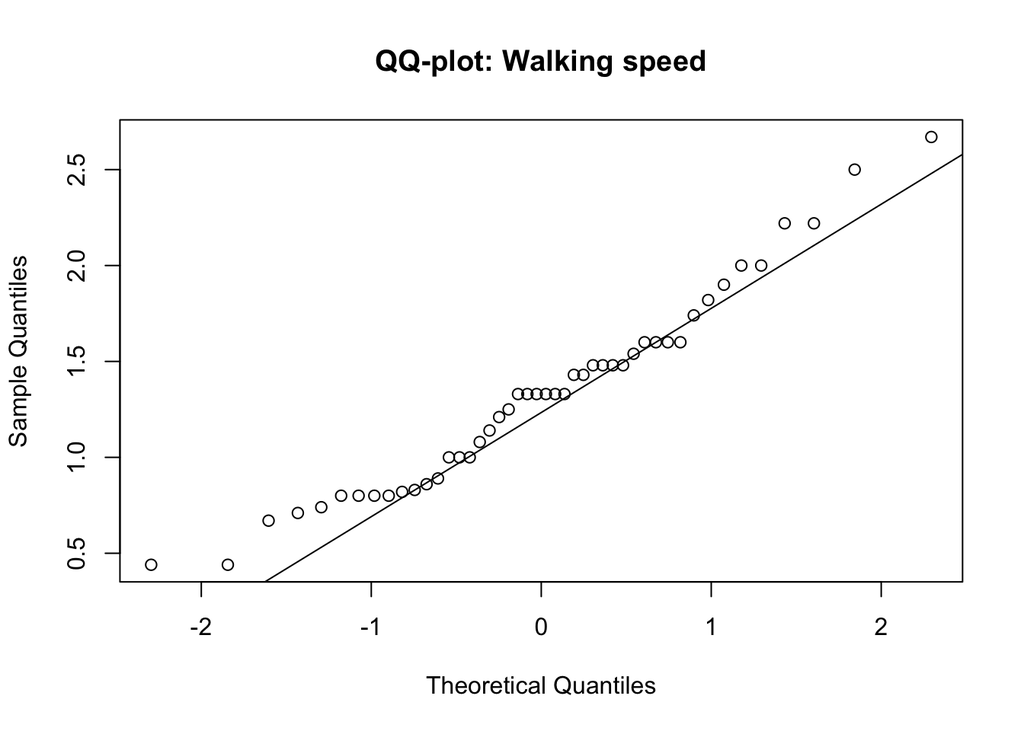

```r
qqnorm(data$walking_speed, main = "QQ-plot: Walking speed")
qqline(data$walking_speed)
```

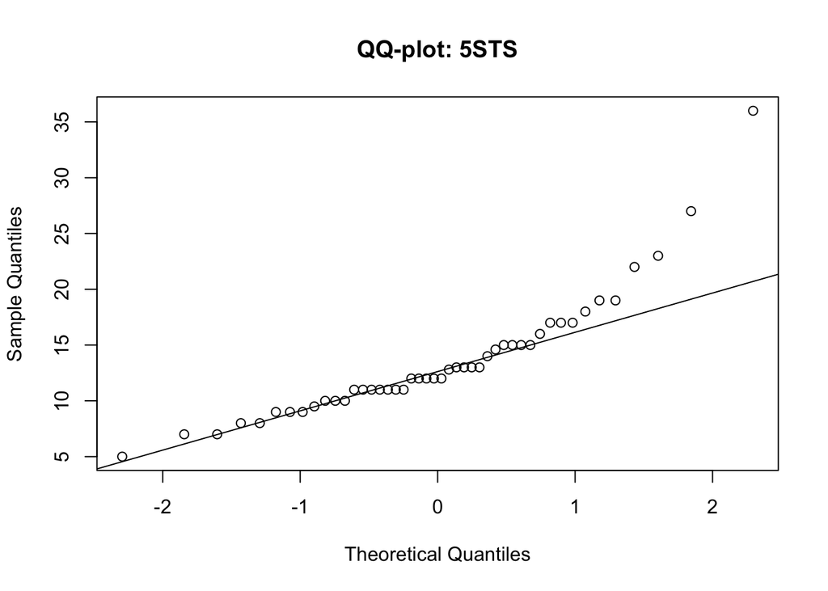

```r
qqnorm(data$time_5_raise_chair, main = "QQ-plot: 5STS")
qqline(data$time_5_raise_chair)
```

```r
# Shapiro-Wilk test
shapiro.test(data$handgrip_strength)
```

```
##
##  Shapiro-Wilk normality test
##
## data:  data$handgrip_strength
## W = 0.9854, p-value = 0.8255
```

```r
shapiro.test(data$walking_speed)
```

```
##
##  Shapiro-Wilk normality test
##
## data:  data$walking_speed
## W = 0.9636, p-value = 0.1582
```

```r
shapiro.test(data$time_5_raise_chair)
```

```
##
##  Shapiro-Wilk normality test
##
## data:  data$time_5_raise_chair
## W = 0.85605, p-value = 4.433e-05
```

Grip strength and walking speed appear to follow a normally distribution based on QQ-plots, while 5STS deviated from normality. These observations was confirmed by the Shapiro-Wilk test (handgrip: p = 0.8255; walking speed: p = 0.1582; 5STS: p = 4.433e-05). Therefore, Spearman’s correlation will be used to assess the associations.

### 5.3. Correlation analysis

Spearman’s correlation was used to assess the association between handgrip strength and functional performance variables.

```r
# Correlation test
# Handgrip vs walking speed
cor.test(data$handgrip_strength, data$walking_speed, method = "spearman")
```

```
##
##  Spearman's rank correlation rho
##
## data:  data$handgrip_strength and data$walking_speed
## S = 9224.4, p-value = 0.002779
## alternative hypothesis: true rho is not equal to 0
## sample estimates:
##       rho
## 0.4311179
```

```r
# Handgrip vs 5STS
cor.test(data$handgrip_strength, data$time_5_raise_chair, method = "spearman")
```

```
##
##  Spearman's rank correlation rho
##
## data:  data$handgrip_strength and data$time_5_raise_chair
## S = 21446, p-value = 0.02877
## alternative hypothesis: true rho is not equal to 0
## sample estimates:
##        rho
## -0.3226009
```

### 5.3.1 Interpretation of results

Spearman correlation analysis revealed a significant positive association between handgrip strength and walking speed (rho = 0.43, p = 0.003), indicating that higher muscle strength is associated with better walking performance.

A significant negative association was also observed between handgrip strength and 5STS performance (rho = -0.32, p = 0.029), meaning that higher handgrip strength is associated with lower completion time and therefore better functional performance.

Overall, these results suggest that greater muscle strength is associated with improved functional performance in patients with ILD.

### 5.4. Adjusted analysis

To adjust for potential confounding factors such as age and sex.

```r
model_walk <- lm(walking_speed_mps ~ handgrip_strength + age_years + gender, data = data)
summary(model_walk)
```

```
##
## Call:
## lm(formula = walking_speed_mps ~ handgrip_strength + age_years +
##     gender, data = data)
##
## Residuals:
##      Min       1Q   Median       3Q      Max
## -0.88829 -0.27784 -0.08092  0.30896  1.06281
##
## Coefficients:
##                    Estimate Std. Error t value Pr(>|t|)
## (Intercept)        2.924453   1.014338   2.883  0.00618 **
## handgrip_strength  0.020493   0.009715   2.109  0.04091 *
## age_years         -0.028132   0.012010  -2.342  0.02398 *
## genderM           -0.072944   0.205626  -0.355  0.72456
## ---
## Signif. codes:  0 '***' 0.001 '**' 0.01 '*' 0.05 '.' 0.1 ' ' 1
##
## Residual standard error: 0.4516 on 42 degrees of freedom
## Multiple R-squared:  0.2904, Adjusted R-squared:  0.2397
## F-statistic: 5.729 on 3 and 42 DF,  p-value: 0.002222
```

```r
model_5sts <- lm(time_5_raise_chair ~ handgrip_strength + age_years + gender, data = data)
summary(model_5sts)
```

```
##
## Call:
## lm(formula = time_5_raise_chair ~ handgrip_strength + age_years +
##     gender, data = data)
##
## Residuals:
##     Min      1Q  Median      3Q     Max
## -8.1386 -3.0758 -0.1802  1.7851 16.8422
##
## Coefficients:
##                   Estimate Std. Error t value Pr(>|t|)
## (Intercept)        -9.2543    10.6254  -0.871  0.38873
## handgrip_strength  -0.1112     0.1018  -1.093  0.28064
## age_years           0.3647     0.1258   2.899  0.00593 **
## genderM            -2.2095     2.1540  -1.026  0.31086
## ---
## Signif. codes:  0 '***' 0.001 '**' 0.01 '*' 0.05 '.' 0.1 ' ' 1
##
## Residual standard error: 4.731 on 42 degrees of freedom
## Multiple R-squared:  0.3151, Adjusted R-squared:  0.2662
## F-statistic:  6.44 on 3 and 42 DF,  p-value: 0.001094
```

### 5.4.1 Interpretation of results

After adjustment for age and gender, handgrip strength remained significantly associated with walking speed (p = 0.04091), indicating that higher muscle strength is independently associated with better walking performance.

Age was also significantly associated with walking speed (p = 0.02398), with older patients showing lower walking speed. In contrast, gender was not significantly associated with walking speed.

## 6. Conclusion

This analysis aimed to assess the association between handgrip strength and functional performance in patients with ILD.

Significant associations were observed between handgrip strength and both walking speed and 5STS performance, with higher muscle strength associated with better functional performance.

After adjustment for age and gender, the association between handgrip strength and walking speed remained significant, indicating that muscle strength is independently associated with walking performance. Age was also significantly associated with walking speed.

In contrast, the association between handgrip strength and 5STS was no longer significant after adjustment, suggesting that this relationship may be partly explained by age.

Overall, these findings suggest that handgrip strength may be associated with functional performance, particularly walking ability, in patients with ILD.